# STAT 311 Reference Sheet: R Studio Help

[-> Homepage](https://t3rra-byt3.github.io/)

### How do I create a new Rmd File?

- From the toolbar on the top in RStudio, select File > New File > R Markdown

[figure not shown]

- In the prompt window that pops up, select From Template and then select the appropriate template. You will be prompted for the name of a new folder (directory) to save the template in. For example, Lab1 could be a good choice for the name of your first lab and it will save in your HOME directory by default.

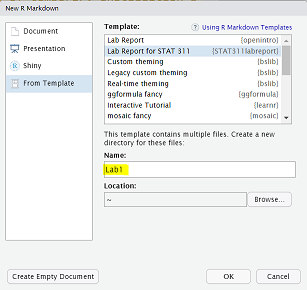

- A sample document should pop up (see image below) in the Source Editor pane on the top left.

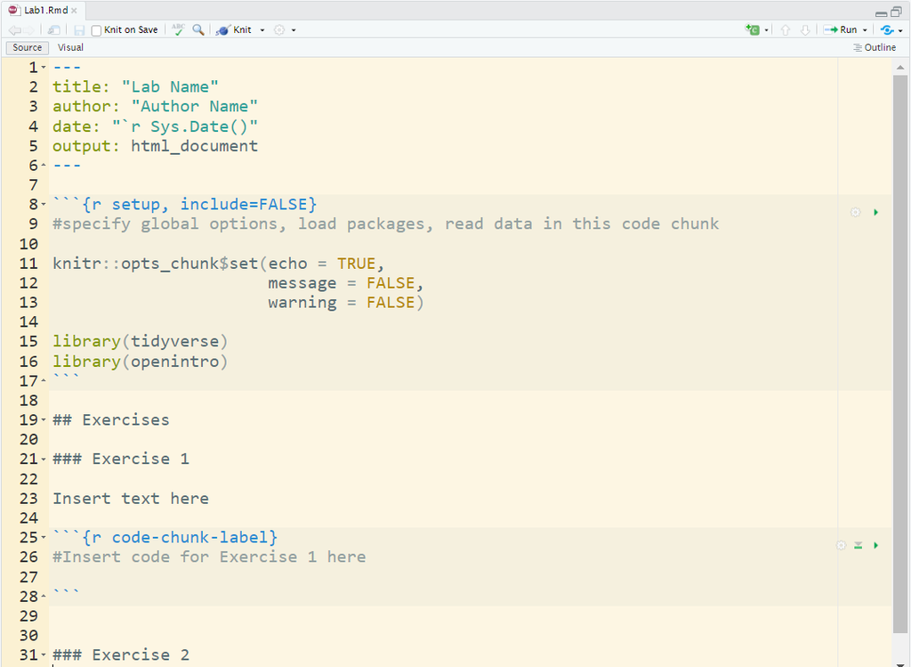

**Note that**

- In the parts of the document with a yellow background, you may type text as you would in a Word document. In the parts of the document with a gray background - called code chunks - you can type R code as you would type it in the Console.

### How do I create a new subfolder in RStudio?

- Press the “New Folder” Icon.

### How do I copy to a directory?

- A directory, or subfolder, can be created using the above method. When copying, press the square select icon next to the file, then press the **More** Icon, and select **Copy To**, then navigate to the desired directory.

### How do I run all of my code?

- Press the “Knit” Button and wait for code to render in the Viewer Pane

### How do I run a few lines of code at a time?

- You can run a few lines at a time **in the Console** to make sure they are working by:
  - Placing your cursor on the specific line of code and pressing Ctrl-Enter or Cmd-Enter
  - Placing your cursor on the specific line of code and pressing the “Run” button in the upper right hand corner of the R Markdown file
  - By clicking on the green arrow at the top right hand corner of the code chunk

### How do I download files for submission?

- First, go ahead and download a copy of each file to your computer by following the instructions below:
- Check the box corresponding to the file you wish to download in the Files pane. (**Note:** It is simpler to download the files one at a time to avoid dealing with compressed files.)
- Then from the drop down menu in the pane select More -> Export to download the file. Repeat for each file you wish to download.

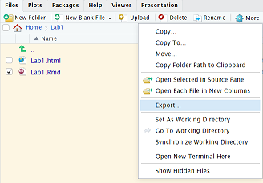

- Upload your files (both the .Rmd and .html separately) from your computer to the CANVAS dropbox by the due date!

### How do I end my RStudio Session?

- To quit RStudio, type `q()` in the Console window or click on the power button icon in the top right corner
- Then go back to JupyterHub and logout

[figure not shown]

### Common Mistakes

- When an R Markdown document is knitting, it only has access to the variables that are created inside of the R Markdown document itself (it doesn’t have access to variables created in the Console)